# Data Analysis Project

Wayne Monical

December 10, 2019

Cleaning this data by omitting the rows where there’s no entry for salary

```r
## removing the empty salary positions
baseball_df <- as.data.frame(baseball)

baseball_df <- filter(baseball_df, !is.na(salary))
summary(baseball_df$salary)
```

```
##     Min.  1st Qu.   Median     Mean  3rd Qu.     Max.
##   480000   490600  1100000  3683130  5075000 30000000
```

#### Auxillary Variables

Creating Auxillary Variables

1. AVG: career batting average, the number of hits divided by number of at-bats
2. OBP: career on base percentage, (hits + walks)/(at bats + walks)

Career Averages, divided by years:

3. At-bats
4. Hits
5. Home runs
6. Runs scored
7. RBI’s

```r
years <- baseball_df$years

# I'm gonna use "_car" short for career
AVG <- baseball_df$H / baseball_df$AB
OBP <- (baseball_df$H + baseball_df$BB) / (baseball_df$AB + baseball_df$BB)
AB_car <- baseball_df$CAB / years
H_car <- baseball_df$CH / years
HR_car <- baseball_df$CHR / years
R_car <- baseball_df$CR / years
RBI_car <- baseball_df$CRBI / years
```

#### Data Normalization

```r
log_salary <- log(baseball_df$salary)
log_CR <- log(1 + baseball_df$CR)

baseball_num <- select(baseball_df, G.x, GS, InnOuts, PO,
                       A, E, DP, G.y, AB, R, H, X2B, X3B,
                       HR, RBI, SB, CS, BB, SO, IBB, HBP,
                       SH, SF, GIDP, CAB, CH, CHR, CR, CRBI,
                       CBB)

# with auxillary variables
baseball_num <- mutate(baseball_num,
                       AVG, OBP, AB_car, H_car, HR_car,
                       R_car ,RBI_car, log_salary, log_CR)
```

Normalizing Data

```r
baseball_mat <- as.matrix(baseball_num)
baseball_norm <- baseball_mat

for(j in 1:length(baseball_num)){
  temp_vec <- baseball_mat[, j]
  temp_mean <- mean(temp_vec)
  temp_sd <- sd(temp_vec)

  temp_vec <- (temp_vec - temp_mean)/temp_sd

  baseball_norm[,j] <- temp_vec
}

baseball_norm <- as.data.frame(baseball_norm)
```

#### Dummy Variables

Years are transformed into: 0-2, 3-5, 6+ (so two dummy variables) Positions are transformed into: four 0/1 dummy variables, coded 1 for players who consistently played second base or shortstop (i.e., middle infielders, MI), catcher (C), center field (CF), or designated hitter (DH)

There’s no designated hitter entry

Making Dummy Variables

```r
# years dummy variable
years <- baseball_df$years
n <- length(years)

# empty vectors
year_dum35 <- rep(0, n)
year_dum6 <- rep(0, n)

# filling out
year_dum35[years > 2 & years < 6] <- 1
year_dum6[years > 5] <- 1

# now for position dummy variables
position <- baseball_df$POS

# empty vectors
mi_dum <- rep(0, n)
catcher_dum  <- rep(0, n)
centerf_dum  <- rep(0, n)

# filling them out
mi_dum[position == "2B" | position == "SS" | position == "12" | position == "OS"] <- 1
catcher_dum[position == "C"]  <- 1
centerf_dum[position == "CF"]  <- 1
```

Finalizing the data matrix

```r
bb_final <- mutate(baseball_norm, year_dum6,
                   year_dum35, mi_dum, catcher_dum,
                   centerf_dum)
```

## Analysis

Fitting a simple model predicting salary(logged) from dummy variables indicating length of career, career runs(logged), and interaction between the two. I originally calculated years as a continuous variable, but I ran into problems with linear dependencies later on, and have here switched to the dummy variables instead.

```r
# making a smaller data frame from the larger one
small_df <- select(bb_final, log_salary, year_dum6, year_dum35, log_CR)

# breaking the columns into vectors
log_CR <- small_df$log_CR
year6_logCR_interaction <- year_dum6 * log_CR
year35_logCR_interaction <- year_dum35 * log_CR

small_df <- mutate(small_df, year6_logCR_interaction, year35_logCR_interaction)


# creating a model based on those vectors
lm_small <- lm(log_salary ~ ., data = small_df)
summary(lm_small)
```

```
##
## Call:
## lm(formula = log_salary ~ ., data = small_df)
##
## Residuals:
##      Min       1Q   Median       3Q      Max
## -2.28227 -0.25294 -0.04086  0.30168  2.19641
##
## Coefficients:
##                          Estimate Std. Error t value Pr(>|t|)
## (Intercept)              -0.76549    0.14674  -5.217 2.88e-07 ***
## year_dum6                 0.77467    0.15707   4.932 1.18e-06 ***
## year_dum35                0.19170    0.15849   1.210   0.2271
## log_CR                    0.08383    0.08934   0.938   0.3486
## year6_logCR_interaction   0.90160    0.11037   8.169 3.78e-15 ***
## year35_logCR_interaction  0.23912    0.11389   2.100   0.0364 *
## ---
## Signif. codes:  0 '***' 0.001 '**' 0.01 '*' 0.05 '.' 0.1 ' ' 1
##
## Residual standard error: 0.5503 on 415 degrees of freedom
## Multiple R-squared:  0.7008, Adjusted R-squared:  0.6971
## F-statistic: 194.4 on 5 and 415 DF,  p-value: < 2.2e-16
```

Graphically, this looks like three lines fitting the three types of data.

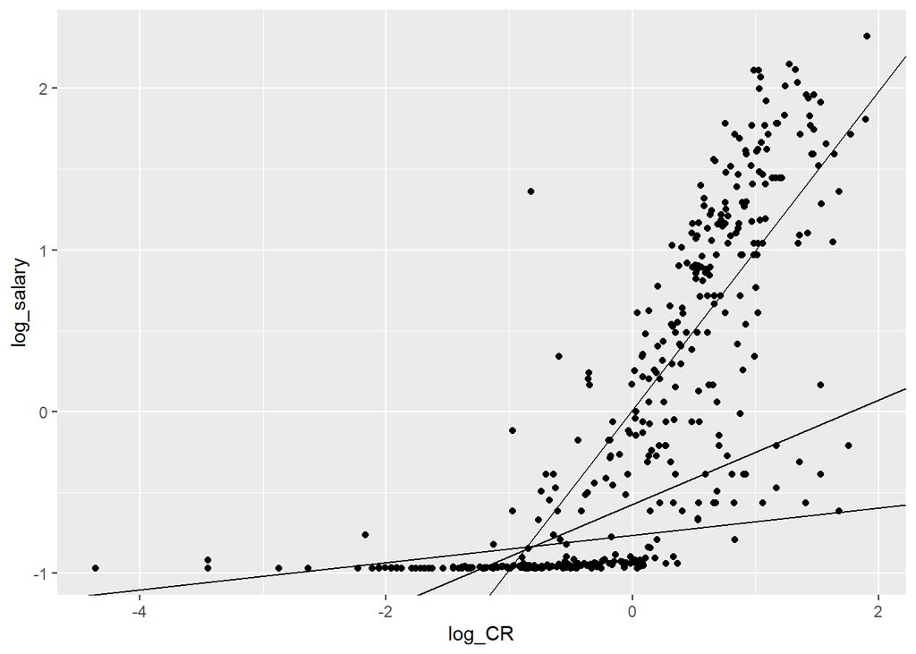

```r
ggplot(data = small_df, aes(x = log_CR, y = log_salary)) +
  geom_point() + geom_abline(slope = 0.08383, intercept = -0.7654) +
  geom_abline(intercept = -0.7654 + 0.77467, slope = 0.08383 + 0.90160) +
  geom_abline(intercept = -0.76549 + 0.19170, slope = 0.08383 + 0.23912)
```

Let’s look for high leverage points(hat values 2-3 times the average), outliers, and influence. The green line is the average hat value. The orange line is three times the average hat value, and I’m considering hat-values well above that line suspiciously high.

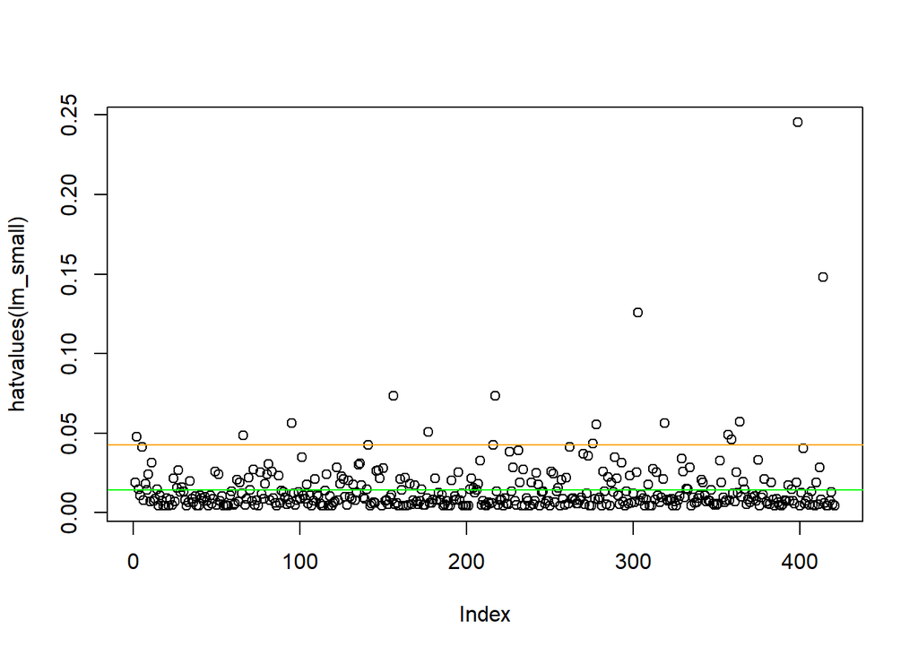

```r
# hat values
hat_mean <- mean(hatvalues(lm_small))
plot(hatvalues(lm_small))
abline(hat_mean, 0, col = "green")
abline(3* hat_mean, 0, col = "orange")
```

It looks like there are 3 points with really really high hat values that I’d like to consider tossing, namely 399, 303, and 414

```r
head(sort(hatvalues(lm_small), decreasing = TRUE), n = 7)
```

```
##        399        414        303        156        217        364         95
## 0.24528186 0.14829839 0.12598716 0.07327794 0.07327794 0.05732340 0.05652658
```

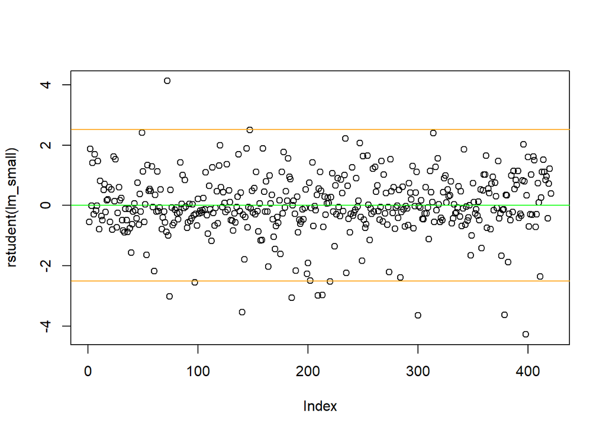

```r
r_student_sd <- sd(rstudent(lm_small))
plot(rstudent(lm_small))
abline(r_student_sd * 2.5, 0, col = "orange")
abline(r_student_sd * -2.5, 0, col = "orange")
abline(0, 0, col = "green")
```

Again, we see points 398, 379, and 72

```r
head(sort(abs(rstudent(lm_small)), decreasing = TRUE), n = 7)
```

```
##      398       72      300      379      140      185       74
## 4.273113 4.124243 3.638245 3.634176 3.532747 3.060776 3.012461
```

Graphing studentized residuals versus leverage. In this graph, we can also see the influence of through the size of the bubbles. Points 72, 414, and 398 have lots of influence. Here, I can see that while 399 has a very high hat-value, its studentized residual is small enough so that 399 does not exert undue influence on the model.

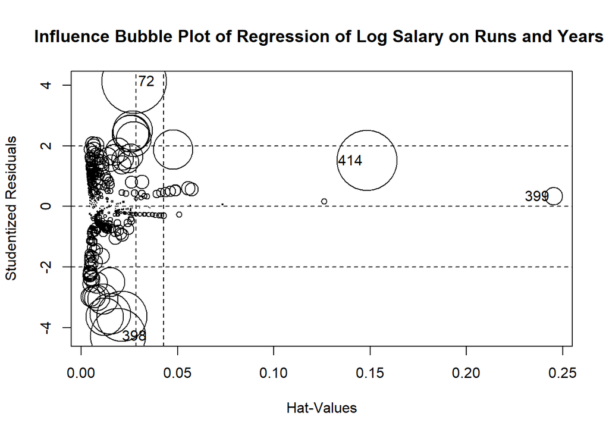

|  | StudRes | Hat | CookD |
| --- | --- | --- | --- |
| 72 | 4.1242435 | 0.02738064 | 0.076842127 |
| 398 | -4.2731130 | 0.01891365 | 0.056326027 |
| 399 | 0.3341188 | 0.24528186 | 0.006059851 |
| 414 | 1.5133196 | 0.14829839 | 0.066253833 |

```r
influencePlot(lm_small, main = "Influence Bubble Plot of Regression of Log Salary on Runs and Years ")
```

#### Regression without the Influential Points

What’s the point of identifying the bad points if I’m not going to do a regression without them? I’m omitting points 398, 72, and 414. While point 399 has a very high at value and leverage, it’s studentized residual looks very good.

```r
## it's called small_df_cleaner because it's a smaller data frame, and cleaner in that it's scrubbed of bad values
small_df_cleaner <- slice(small_df, -72, -398, -414)

# primary terms
logsalary_cleaner <- small_df_cleaner$log_salary
year35_cleaner <- small_df_cleaner$year_dum35
year6_cleaner <- small_df_cleaner$year_dum6
log_CR_cleaner <- small_df_cleaner$log_CR

# interaction terms
logCR_year35_cleaner <- year35_cleaner * log_CR_cleaner
logCR_year6_cleaner <- year6_cleaner * log_CR_cleaner

lm_small_cleaner <- lm(logsalary_cleaner ~ year35_cleaner + year6_cleaner + log_CR_cleaner + logCR_year35_cleaner + logCR_year6_cleaner)
summary(lm_small_cleaner)
```

```
##
## Call:
## lm(formula = logsalary_cleaner ~ year35_cleaner + year6_cleaner +
##     log_CR_cleaner + logCR_year35_cleaner + logCR_year6_cleaner)
##
## Residuals:
##      Min       1Q   Median       3Q      Max
## -1.99673 -0.25782 -0.02544  0.31428  1.31021
##
## Coefficients:
##                      Estimate Std. Error t value Pr(>|t|)
## (Intercept)          -0.85666    0.14235  -6.018 3.91e-09 ***
## year35_cleaner        0.29892    0.15384   1.943  0.05269 .
## year6_cleaner         0.85428    0.15218   5.614 3.64e-08 ***
## log_CR_cleaner        0.04805    0.08608   0.558  0.57701
## logCR_year35_cleaner  0.31832    0.11294   2.818  0.00506 **
## logCR_year6_cleaner   0.97041    0.10644   9.117  < 2e-16 ***
## ---
## Signif. codes:  0 '***' 0.001 '**' 0.01 '*' 0.05 '.' 0.1 ' ' 1
##
## Residual standard error: 0.5277 on 412 degrees of freedom
## Multiple R-squared:  0.7248, Adjusted R-squared:  0.7215
## F-statistic: 217.1 on 5 and 412 DF,  p-value: < 2.2e-16
```

In order to better graph the qualitative nature of the years dummy variables, I’m combining them into one variable for the purpose of graphing.

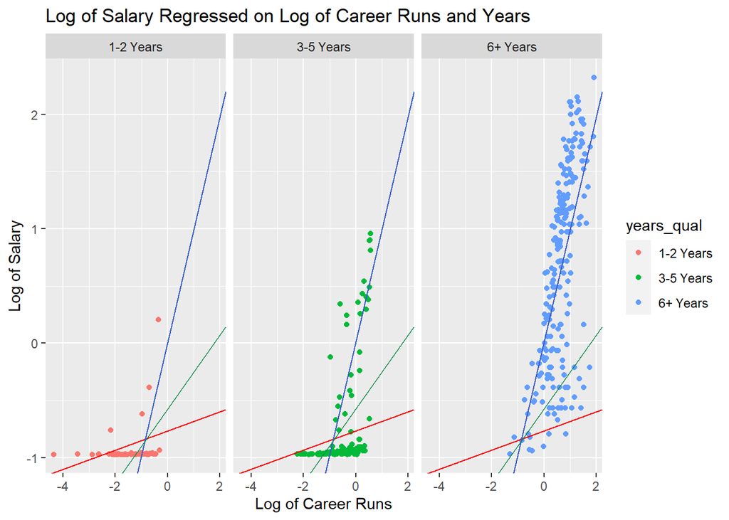

```r
# one variable from two
years_qual <- small_df_cleaner$year_dum35 + 2 * small_df_cleaner$year_dum6

# labelling
years_qual[years_qual == 0] <- "1-2 Years"
years_qual[years_qual == 1] <- "3-5 Years"
years_qual[years_qual == 2] <- "6+ Years"

small_graph_df <- mutate(small_df_cleaner, years_qual)


ggplot(data = small_graph_df, aes(x =  log_CR, y = log_salary)) +
  geom_point(aes(color = years_qual)) +
  xlab("Log of Career Runs") +
  ylab("Log of Salary") + facet_grid(.~years_qual) +
  geom_abline(slope = 0.08383, intercept = -0.7654, color = "red") +
  geom_abline(intercept = -0.7654 + 0.77467, slope = 0.08383 + 0.90160, color = "royalblue3") +
  geom_abline(intercept = -0.76549 + 0.19170, slope = 0.08383 + 0.23912, color = "springgreen4") +
  ggtitle("Log of Salary Regressed on Log of Career Runs and Years")
```

Fitting a linear least-squares regress of log salary on all explanatory variables. While the plot below doesn’t display influence directly, like the bubble plot from before, it’s much cleaner. We see the troublesome points 300, 379, and 398.

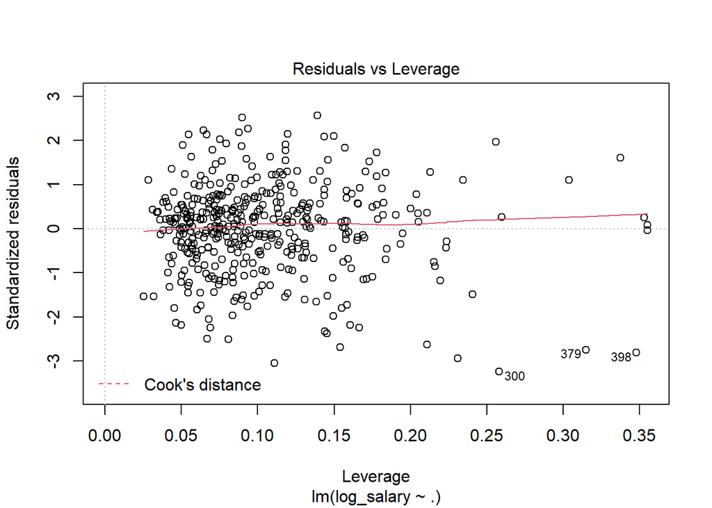

```r
lm_all <- lm(log_salary ~ ., data = bb_final)


plot(lm_all, which  = 5)
```

Here, I notice that many of the variables are highly correlated. While many values have a covariance of zero, and all values have a covariance of one with themselves, there is a large number of values between 0.6 and 0.99, what I would consider highly correlation.

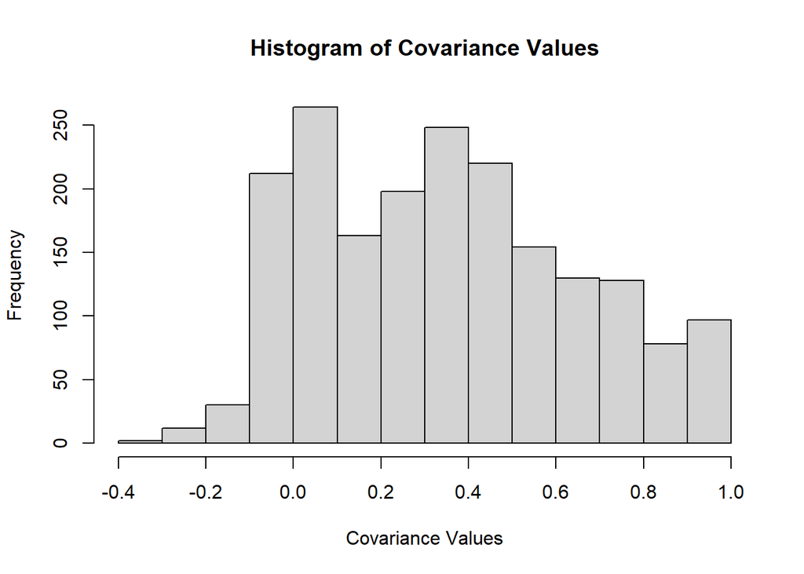

```r
hist(cov(as.matrix(bb_final)), xlab = "Covariance Values", main = "Histogram of Covariance Values")
```

4. Finding the 10 best models for each size. To do this, I’m going to find the ten best models of each size with a forward search and the ten best models of each size with a backwards search, then find the 10 best models from those twenty of each model size. For models of the same size, I’m going to use the simple criterion of the highest adjusted R-squared to determine which model is best.

```r
# use nbest to specify the number of subsets of each size to record
# use nvmax to specify the maximum size of subsets to examine

# forward search
regfit.bb.forward <- regsubsets(log_salary ~ ., data = bb_final, method = "forward", nbest = 10, nvmax = 44)
regfit.bb.forward.summary <- summary(regfit.bb.forward)

# backwards search
regfit.bb.backward <- regsubsets(log_salary ~ ., data = bb_final, method = "backward", nbest = 10, nvmax = 44)
regfit.bb.backward.summary <- summary(regfit.bb.backward)
```

```r
# making a matrix with columns for type of search(forward or backwards),
#      index, number of variables, and adjusted r-squared

# lengths
n_forward <-length(regfit.bb.forward.summary$adjr2)
n_backward <- length(regfit.bb.backward.summary$adjr2)

# types: forward is 0, backward is 1
type_forward <- rep(0, n_forward)
type_backward <- rep(1, n_backward)


# index
index_forward <- 1:n_forward
index_backward <- 1:n_backward

# number variables
num_variables_forward <- rowSums(regfit.bb.forward.summary$which)
num_variables_backward <- rowSums(regfit.bb.backward.summary$which)

# adjusted r-square
adr2_forward <- regfit.bb.forward.summary$adjr2
adr2_backward <- regfit.bb.backward.summary$adjr2

# in a matrix
n_mat <- n_forward + n_backward

# model id
model_id <- 1:n_mat


mat_regfit <- matrix(c(model_id, type_forward, type_backward, index_forward, index_backward,
                       num_variables_forward, num_variables_backward, adr2_forward, adr2_backward),
                     nrow = n_mat,
                     dimnames = list(NULL, c("id", "type", "index", "variables", "adjr2")))
head(mat_regfit)
```

```
##      id type index variables     adjr2
## [1,]  1    0     1         2 0.5648365
## [2,]  2    0     2         2 0.5512639
## [3,]  3    0     3         2 0.5510138
## [4,]  4    0     4         2 0.5457725
## [5,]  5    0     5         2 0.5453000
## [6,]  6    0     6         2 0.5422182
```

Now, I’ll find the ten largest R-squares for each model size. The original matrix of the ten best models from both the forward and backward searches has 769 rows. I’ve cut that down to 412 rows. I’ve realized now that the number of models generated this way is not a perfect multiplication of 44 possible model sizes times 10 models, because for some model sizes, having ten different models isn’t possible.

```r
df_regfit <- as.data.frame(mat_regfit)


# this will be the matrix of the best models of each size.
df_regfit_best <- df_regfit
regfit_best_logical <- rep(FALSE, n_mat)


for(k in 2:45){
  temp_df <- filter(df_regfit, variables == k)

  # finding the 10 best adjr2 (adjusted r squared) at each variable count
  temp_df <- arrange(temp_df, desc(adjr2))
  temp_df <- slice(temp_df, 1:10)

  best_id <- temp_df$id


    # recording which is best
  for(j in 1:10){
      regfit_best_logical[df_regfit$id == best_id[j]] <- TRUE
  }
}

df_regfit_best <- df_regfit_best[regfit_best_logical,]

head(df_regfit_best, n = 9)
```

|  | id | type | index | variables | adjr2 |
| --- | --- | --- | --- | --- | --- |
| 1 | 1 | 0 | 1 | 2 | 0.5648365 |
| 2 | 2 | 0 | 2 | 2 | 0.5512639 |
| 3 | 3 | 0 | 3 | 2 | 0.5510138 |
| 4 | 4 | 0 | 4 | 2 | 0.5457725 |
| 5 | 5 | 0 | 5 | 2 | 0.5453000 |
| 6 | 6 | 0 | 6 | 2 | 0.5422182 |
| 7 | 7 | 0 | 7 | 2 | 0.5271247 |
| 11 | 11 | 0 | 11 | 3 | 0.6321292 |
| 12 | 12 | 0 | 12 | 3 | 0.6313720 |

Plotting the 10 best models of each size’s Adjsuted R-square value

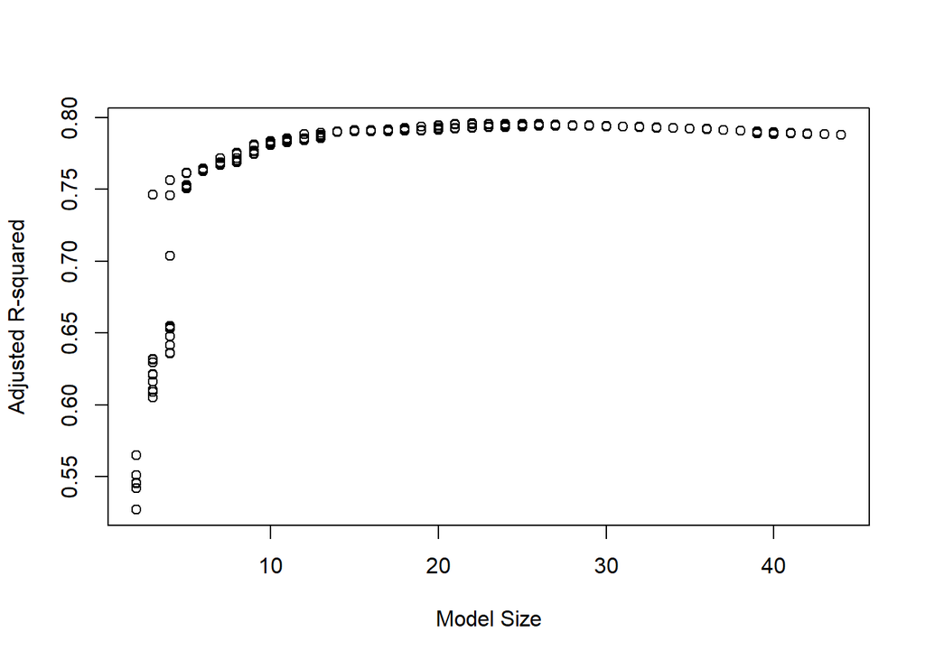

```r
plot(df_regfit_best$variables, df_regfit_best$adjr2, xlab = "Model Size", ylab = "Adjusted R-squared")
```

5. Using BIC to find the 5 best models from the previous step. The first thing to do in this process is to add BIC to the matrix that I used to evaluate the models.

```r
all_bic <- c(regfit.bb.forward.summary$bic, regfit.bb.backward.summary$bic)

# filtering for the best 10 models of each size
best_bic <- all_bic[regfit_best_logical]

# adding it to the dataframe
df_regfit_best <- mutate(df_regfit_best, best_bic)

head(df_regfit_best)
```

|  | id | type | index | variables | adjr2 | best_bic |
| --- | --- | --- | --- | --- | --- | --- |
| 1 | 1 | 0 | 1 | 2 | 0.5648365 | -339.2044 |
| 2 | 2 | 0 | 2 | 2 | 0.5512639 | -326.2742 |
| 3 | 3 | 0 | 3 | 2 | 0.5510138 | -326.0396 |
| 4 | 4 | 0 | 4 | 2 | 0.5457725 | -321.1534 |
| 5 | 5 | 0 | 5 | 2 | 0.5453000 | -320.7158 |
| 6 | 6 | 0 | 6 | 2 | 0.5422182 | -317.8720 |

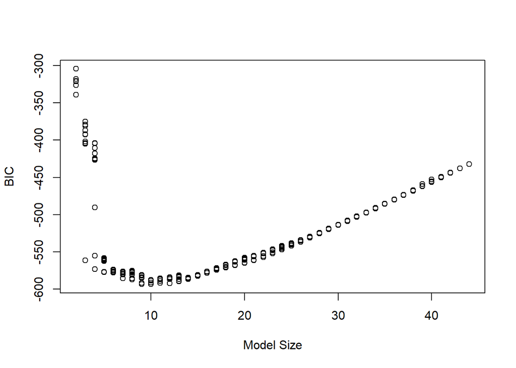

```r
plot(df_regfit_best$variables, df_regfit_best$best_bic, xlab = "Model Size", ylab = "BIC")
```

Finding the smallest 5 BIC. What I like about the one’s that I’ve found is how diverse in model size there are; there is only one model size repeat. Here they are displayed, ranked by BIC.Interestingly, they’re almost all from the backwards search.

```r
best_bic_df <- arrange(df_regfit_best, -desc(best_bic))
best_bic_df <- slice(best_bic_df, 1:5)

head(best_bic_df)
```

|  | id | type | index | variables | adjr2 | best_bic |
| --- | --- | --- | --- | --- | --- | --- |
| 1 | 472 | 1 | 79 | 10 | 0.7838093 | -593.4944 |
| 2 | 462 | 1 | 69 | 9 | 0.7811958 | -593.4551 |
| 3 | 492 | 1 | 99 | 12 | 0.7883843 | -592.4676 |
| 4 | 71 | 0 | 71 | 9 | 0.7804333 | -591.9906 |
| 5 | 482 | 1 | 89 | 11 | 0.7855554 | -591.8915 |